# MATH 3080 Lab Project 8

# Problem 4 (Verzani problem 12.31)

*What does R output when there is not enough data to estimate the parameters and an error term? We check with a simple example. In checking a comment that everything is better with butter on it, a student asks four people to rate the four combinations of bread and corn with and without butter. The data collected is:*

```r
d <- data.frame(
  rating = c(8, 6, 8, 4),
  food = gl(2, 2, 4, labels = c("bread", "corn")),
  butter = gl(2, 1, 4, labels = c("yes", "no"))
)
xtabs(rating ~ butter + food, d)
```

```
##       food
## butter bread corn
##    yes     8    8
##    no      6    4
```

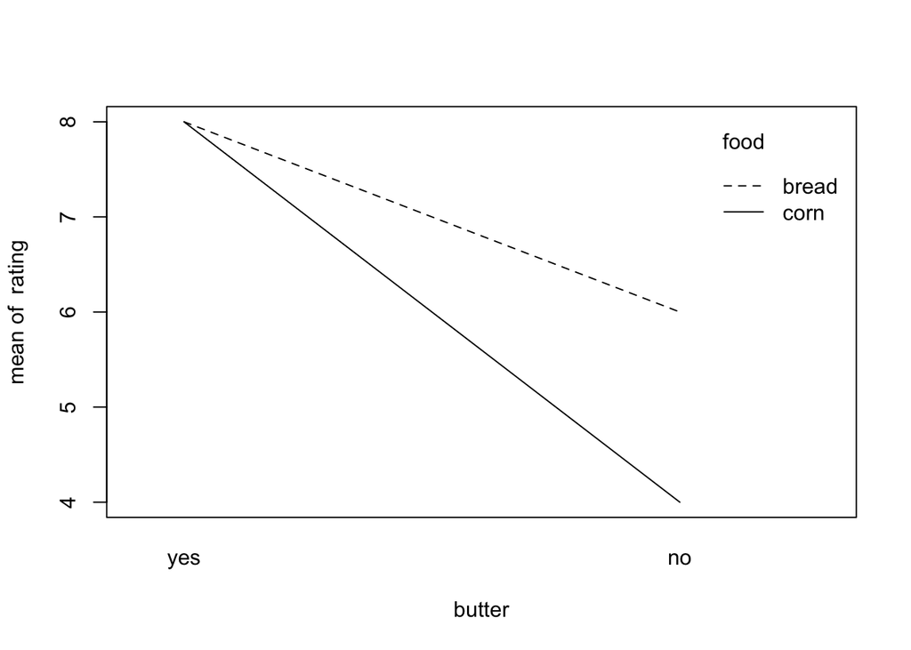

```r
with(d, interaction.plot(butter, food, rating))
```

*Look at the summary of the multiplicative model*

```r
summary(lm(rating ~ butter * food, d))
```

```
##
## Call:
## lm(formula = rating ~ butter * food, data = d)
##
## Residuals:
## ALL 4 residuals are 0: no residual degrees of freedom!
##
## Coefficients:
##                   Estimate Std. Error t value Pr(>|t|)
## (Intercept)              8        NaN     NaN      NaN
## butterno                -2        NaN     NaN      NaN
## foodcorn                 0        NaN     NaN      NaN
## butterno:foodcorn       -2        NaN     NaN      NaN
##
## Residual standard error: NaN on 0 degrees of freedom
## Multiple R-squared:      1,  Adjusted R-squared:    NaN
## F-statistic:   NaN on 3 and 0 DF,  p-value: NA
```

*Do the coefficients get estimated? What is the issue then?*